# MADS-DAV · Lesson 6 · Many dimensions

## Check a model on messages where you know the answer

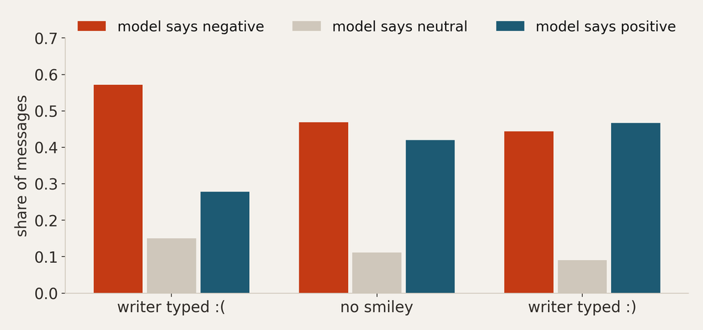

Writers label their own mood: **:)** or **:(**. Take 600 of each, remove the smiley, and let the model read only the words. One message per row: a mood belongs to a message.

It calls 57% of the :( messages negative, but also 44% of the :) messages and 47% of plain ones.

It reads a little of the mood, too little to compare people: their differences would be smaller than its own confusion.

5 / what is one row, when a row is “haha”?

MADS-DAV · 42

● 05 — what is one row, when a row is “haha”?

A picture shows only what the rows contain.

One message is too small to carry who wrote it. Choose the row for the question: sessions for topics, single messages for moods.

Check a choice with a test whose outcome you can predict, like the two halves of a session.

An embedding measures meaning; for who is writing, count characters. Check a borrowed model on cases where you know the answer.

43

Said again. The blob was not a failure of the model, it was the correct answer to a badly posed question: single messages do not carry who wrote them. Changing the row changed what the data could show, and the half-session check told us which row works, without any labels. Then three ways in which a vector measures what it was made for and nothing else: an embedding measures meaning, so it groups by topic and not by person; trigram counts see typing habits, so they win the race for who is writing; and a sentiment model reads somebody else's idea of negative, which here was mostly people with broken software. In your own chat, at the end of notebook 06.4, the same functions run in five cells, each with one question to answer in a sentence. A null result is a finished sentence: single messages from my chat do not separate by author.

▲ question 06

why did k-means find three clusters?

## Because you asked for three. A method that always returns an answer cannot be your evidence.

1 · How much

How much of the data is in the picture you clustered?

2 · In nothing

What do the same steps find in data without any structure?

3 · What are they

Do the groups show up in something you measured another way?

44

Question six, and the reason this lesson ends here. A result we see in projects every year: sentence vectors of 384 numbers, a PCA picture of two components, k-means with K is three, and the conclusion: I found three clusters. When the groups were then checked with features measured another way, regexes, there were no three groups. What is missing is not a technical detail; it is the insight from lessons 4 and 5: if you look with a tool that always finds something, finding something tells you nothing. k-means always returns K groups, on any data. So three groups with K is three is the input, read back. Three questions catch it, and we answer them on the 1,500 messages from question five: how much of the data is in the picture you clustered; what do the same steps give on data without any structure; and what are the groups, checked against something you measured another way. Notebook 06.4, section 6.4.2, and 06.1's section on noise.

■ 6 — why did k-means find three clusters?

the 1,500 messages, PCA, k-means with K=3

## k-means finds three groups in anything

data without structure

np.column_stack([rng.permutation(column) for column in X.T])

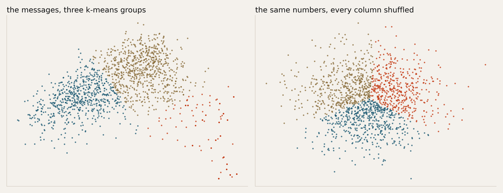

silhouette

A metric [0,1] that shows you how distinct groups are compared to other groups.

1: tight groups, far apart.  
0: groups that run into each other.

Left: the blob from question 5, cut by k-means into three tidy groups. Silhouette 0.48: halfway to 1, which looks like structure.

Right: every column shuffled on its own, so any structure between messages is gone. Three tidy groups again, silhouette 0.34: not much lower.

k-means on all 384 numbers instead of the picture: its three groups score 0.01: in the full data they overlap almost completely.

6 / why did k-means find three clusters?

MADS-DAV · 45

The rescue, rebuilt on the 1,500 messages from question five: the blob, then k-means with K is three on the two-dimensional PCA picture. Three tidy groups. How convincing are they? Your eye is no judge here, and neither is k-means, which finds groups in anything; you need a number you can hold against what the same steps give on data without structure. The silhouette is the usual one. For every point it compares two distances: the average distance to the other points in its own group, and the average distance to the points of the nearest other group. If the own group is much closer, the point scores near 1; if both are about the same, near 0; if the other group is closer, below 0, a point in the wrong group. Averaged over all points, 1 means tight groups far apart and 0 means groups that run into each other. Here the picture scores 0.48, halfway to 1, which in any report would read as decent cluster structure. Now question two from the previous slide: what do the same steps give on data without structure? Make such data from the same numbers: shuffle every column on its own. Each of the 384 columns keeps exactly its own values, but which message a value belongs to is scrambled, so whatever structure there was between the columns is gone by construction. Same PCA, same k-means: three tidy groups again, silhouette 0.34, not far below the real thing. k-means cuts any cloud into K pieces; that is what it does. And run k-means with K is three on all 384 numbers of the real messages instead of on the picture: its three groups have a silhouette of 0.01: in the full data they overlap almost completely. Silhouettes in a two-dimensional picture are high because a picture squeezes points together; that is the same lesson as t-SNE on noise in question two. A low silhouette does not prove there is nothing there: a real difference can still exist without separating cleanly. But the tidy groups in the picture are no evidence for one.

■ 6 — why did k-means find three clusters?

checking the groups against something else

## The three groups are short, medium and long messages

| group | median words | examples | authors |
| --- | --- | --- | --- |
| short | 1 | “!”, “hmm”, “nah”, “D:” | all six |
| medium | 5 | “like it? based on what?” | all six |
| long | 9 | “because I’m a developer”, “i was more expecting a sort of terminal server for CAD users :D” | all six |

k-means did its job: it cut the cloud along the direction that varies most, how much there is in a message, and handed back three slices because three is what it was asked for.

A word count told us what the groups are; in your project it may be a regex. If the groups show up nowhere but in the picture, they belong to the picture.

6 / why did k-means find three clusters?

MADS-DAV · 46

The third question: what are the groups? Check them against something measured in a different way. Here the cheapest such measure is the number of words. The groups are short, medium and long messages: a median of one, five and nine words. And every author is in every group: the share of one author in one group runs from 2 to 41 percent, no group belongs to anyone. So k-means did not fail either. In the picture, the direction that varies most is how much there is in a message: one-word messages like the exclamation mark all embed in roughly the same corner. k-means cut along that direction and returned three slices, because three is what it was asked for. That is a true fact about the data, and a dull one, and it is not the three topics or three people a report would claim. In your own project the check is the same: put the groups next to something you measured another way, a regex, a word count, a label you trust, and read ten messages from each group. If the groups show up nowhere but in the picture, they are the picture's.

■ 6 — why did k-means find three clusters?

384 dimensions, two components

## A picture of 7% is a shadow of 7%

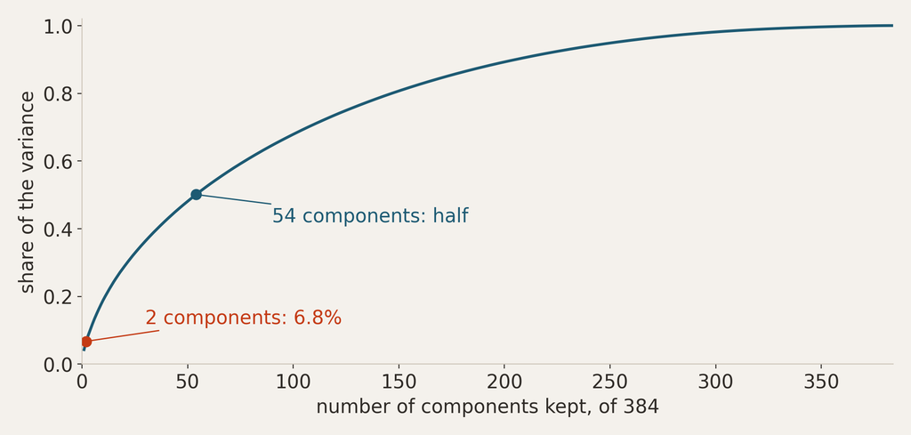

Two PCA components of these sentence vectors hold 6.8% of the variance. Half of it takes 54 components.

A projection only shortens distances. Points far apart in the picture are far apart in the data; points close together in the picture may be far apart in the other 93%.

So groups in a 7% picture say little about groups in the data. Answer the first question before you cluster anything.

6 / why did k-means find three clusters?

MADS-DAV · 47

The first question, and the statistics of PCA from question one. How much of the data is in the picture that was clustered? For these sentence vectors, two components carry 6.8 percent of the variance, and you need 54 components for half of it. That is what sentence embeddings are like: the meaning of a sentence is spread over many directions, none dominant. A projection can only shorten distances, never lengthen them. So two points far apart in the picture are really far apart; but two points close together in the picture may be far apart in the 93 percent you did not draw. Groups in the picture are therefore groups of shadows. This is why 7 percent belongs in the title of the picture, and why it should stop you before the next step. Compare the penguins, where two standardised components held 88 percent: there a picture of the components is a fair picture of the data. Here it is not, and no clustering of the picture can repair that.

■ 6 — why did k-means find three clusters?

the same trap, three times

## If a tool always finds something, finding something proves nothing

lesson 5 · the hunt

Shuffle the labels and test 15 measures: in 42% of the hunts at least one comes out “significant”.

lesson 6 · t-SNE on noise

Clumps in random numbers. k-means scores 0.31 on the picture and 0.016 on the data.

lesson 6 · k-means

Three groups in the real vectors, and three in the same vectors with every column shuffled.

What would this method show me if there were nothing there?

Does what I found show up in something I measured another way?

6 / why did k-means find three clusters?

MADS-DAV · 48

The insight that ties this to the last two lessons, and the one the k-means result was missing. It is not new; it has three costumes. In lesson 5, we hunted for a difference between two groups that were not different: shuffle the labels, test fifteen measures, and in 42 percent of the hunts something comes out significant. In this lesson, t-SNE drew clumps in pure noise, and k-means on that picture scored 0.31 where the data itself scored 0.016. And k-means found three groups in the sentence vectors and three in the same vectors with every column shuffled. Each time, the tool produced a result because producing a result is what it does. Its output cannot tell you whether there was anything to find. Two questions catch all three. What would this method show me if there were nothing there: run the same steps on shuffled labels, shuffled columns, random numbers or other stretches of time, and see whether your finding stands out from that. And does what I found show up in something I measured another way: a regex, a word count, a label, ten messages read by hand. For your projects: every cluster, every picture, every significant difference gets both questions before it goes on a slide.

● 06 — why did k-means find three clusters?

You get the number of clusters you ask for.

k-means always returns K groups, so “K=3 gives three clusters” is not a finding.

Before you report groups: how much of the data is in the picture, and what do the same steps give on data without structure?

Then check what the groups contain, with something measured another way: a word count, a regex, a label.

49

Said again. The number of clusters k-means finds is the number you typed. That makes “I found three clusters” a sentence about your input. A clustering becomes a finding only after three checks: the share of the data in the space you clustered, which for two PCA components of sentence vectors is about 7 percent; the same steps on data without structure, which here gave three groups too; and the groups held against something measured another way, which here turned three clusters into short, medium and long messages. If you want to choose K from the data, the silhouette for several K is a start, but it has the same trap: compare it with what the same K gives on shuffled data.

● summary

up to many dimensions, back down to two

## Map data up to many dimensions, then back down to two to look

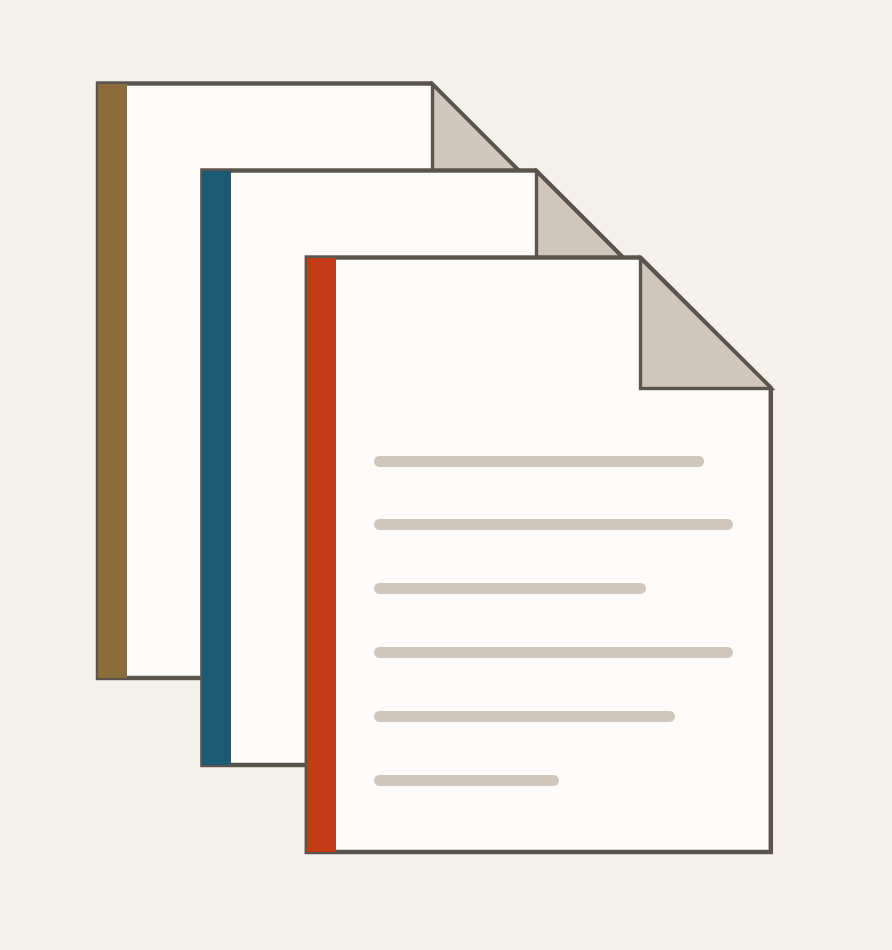

documents

→

embed

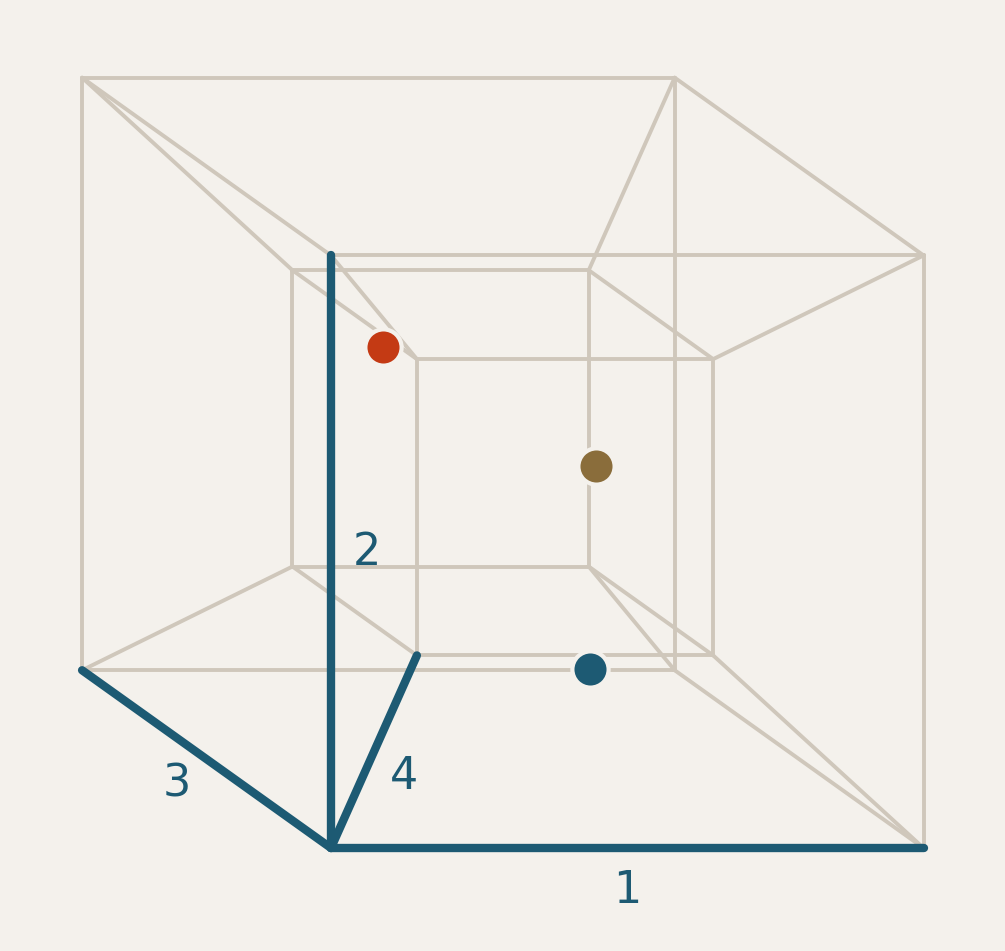

4 of 384 axes

→

reduce

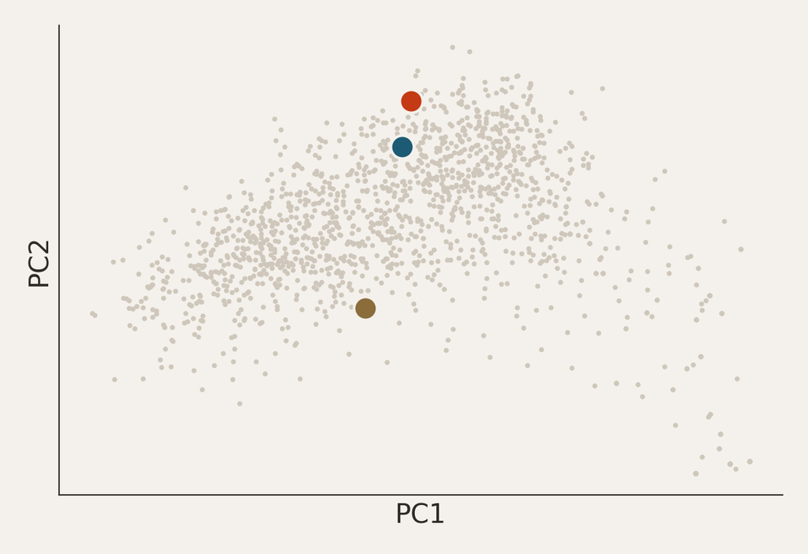

2 axes

Up: count trigrams, run an encoder, or read the pixels. Every message or photo becomes a point with hundreds of coordinates.

There near means similar: searching, comparing and classifying happen in that space, as with the flowers.

Down: PCA or t-SNE, to look. Two axes always hold only part of the space.

summary

MADS-DAV · 50

What this lesson is about, in one picture. We take data that is not numbers yet, documents of any kind, here three chat messages, and map it up into a space with many dimensions: count trigrams, run an encoder like the sentence model or the flower model, or for images simply read the pixels. Each document becomes a point with 384 coordinates. Nobody can draw 384 axes, so the middle panel draws four of them as a hypercube: a cube inside a cube, where the four dark edges from one corner are the four axes, and each document is a point inside it. The real space is the same idea with 380 more axes. That space is where the real work happens: near means similar, so you can search it, compare in it with cosine similarity, and classify in it with a nearest neighbour or a small head. Then, to look at it, we map it back down to two or three dimensions, with PCA or t-SNE. The right panel is the same three documents among the 1,500 messages from question five, on two PCA axes. That picture is for looking, and it is never the whole space: two components of these vectors hold about 7 percent of the variance. So the order of the lesson is the order of every project with this kind of data: decide what one row is, map it up, do the work up there, and come down only to look, saying how much the picture holds.

● summary

two routes, one picture · 3,000 sessions

## A picture tells a story when two routes agree

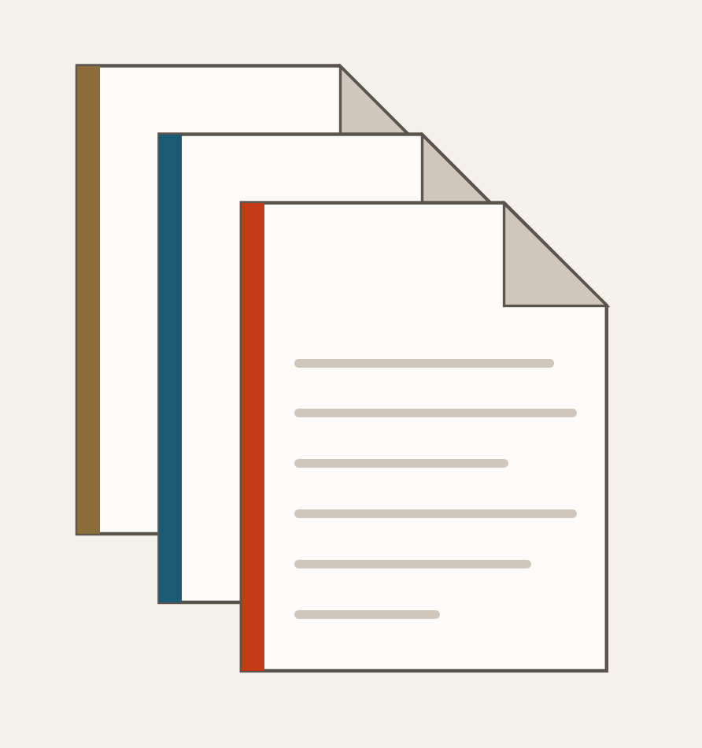

A · documents

f · label

regex or LLM

B · 0/1 labels

|  | topic a |
| --- | --- |
| doc 1 | 1 |
| doc 2 | 1 |
| doc 3 | 0 |

g · embed

colour

C · 384 numbers each

1 [ 0.01, −0.07, …, 0.04]  
2 [−0.13, 0.01, …, 0.07]  
3 [−0.01, −0.04, …, 0.03]

position

t-SNE

D · both routes

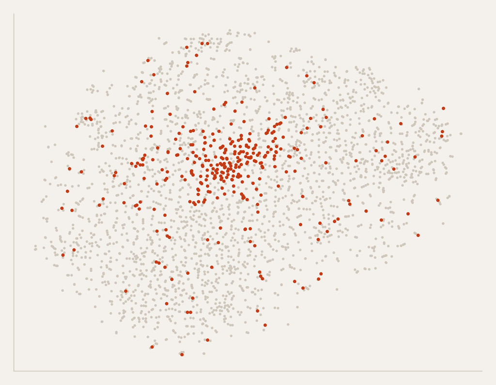

Two routes from the same documents: f gives each a label, g gives each a place.

D draws both: position from g, colour from f. Here topic a is “mentions a phone”, and those sessions gather in one region: 52% have another one as nearest neighbour, against 11.5% by chance.

Two independent routes point at the same group. A scattered colour means f sees something g does not.

summary

MADS-DAV · 51

What story can you tell with all of this? Many projects end in a cloud of points that says nothing. A pattern that does work: take two routes from the same documents and see whether they agree. Route f labels every document: with regexes, as in lesson 5, or by asking a language model to assign labels. That gives a table of zeros and ones, one column per label; the slide shows one, topic a, and in this example topic a is whether a chat session mentions a phone. It could as well be fraud or no fraud, complaint or no complaint. Route g puts every document in a space with many dimensions: a sentence encoder with 384 numbers, as here, or your own 25 regex features. The two routes do not know about each other. The picture D is where they meet: every session is placed by route g, here with t-SNE, and coloured by route f. That makes the diagram commute: for every session, going via its label and going via its place ends at the same dot. If the colour forms its own region, two independent routes have found the same group, and that is a finding you can defend: the encoder never saw the regex, and the regex never saw the encoder. Here it does: of the 3,000 sessions, 11.5 percent mention a phone, and in all 384 dimensions 52 percent of those have another phone session as their nearest neighbour; in the picture it is 47 percent. That is the number without the picture, from question two. If the colour is scattered over the whole cloud, the routes disagree: the label measures something the vectors do not see, like a smiley in lesson 5. In category language, D is the pushout of the two routes: the space of route g in which every point is glued to its label from route f. Two routes that agree leave the glued labels as separate regions; two that disagree glue everything into one smear.

What does PCA show you?

The directions of most spread, in your units. Standardise, and read the scree plot.

When is a flat picture not enough?

When data lies on a curve. t-SNE keeps neighbours, not distances.

How does text become a vector?

By counting. Then read back what did the work: in the Q posts, links.

Why use a model somebody else trained?

Pay for it once, store its vectors, train your part on a laptop.

What is one row, when a row is “haha”?

The unit your question needs. Check it with a test you can predict.

Why did k-means find three clusters?

Because you asked. Ask what the same steps find in nothing.

Lesson 6 · Many dimensions

52

The six questions from the start, with their answers. The notebooks work through each of them: 06.1 PCA, the penguins, the swiss roll, MNIST, perplexity and t-SNE on noise; 06.2 trigram counts and the QAnon claim checked twice; 06.3 the flower cache, cosine similarity, nearest neighbour and a head trained on the cache; 06.4 your own vectors, from the blob through sessions, the race and the sentiment check, ending in five cells on your own chat. For your project: every picture of many dimensions gets the share of the data it holds in its title, and every group you report gets the two questions from the last part: what would the method show if there were nothing there, and does it show up in something you measured another way.

← → or click to move · F full screen · N speaker notes